# 2. Popisná štatistika

Štatistické metódy vyhodnocovania experimentov

William Brach

08.03.2021

# Príklad 1 (diéta)

**Zadanie:** Dietologická poradkyňa zostavila jedálniček a fitness plán pre 202 pacientov z vekovej kategórie 40-50 rokov, zvlášť pre ženy a zvlášť pre mužov. V súbore dieta.xlsx je zaznamenaná váha pacientov na začiatku programu a po trištvrte roku. Dietologička predpokladá, že muži stratia v priemere 15% váhy a ženy 13% váhy. Vhodným testom na danej hladine významnosti overte, či existuje štatisticky významný rozdiel medzi hodnotami pred a po programe bez ohľadu na pohlavie. Okrem toho testujte, či (k = 1) bol predpoklad dietologičky správny pre váhu mužov po diéte.

**Riešenie:**

```r
k <- 1
alpha <- 0.05
df <- read_excel("C://Users//ramang//Developer//SMVE-R//Zadania//5_zadanie_ANOVA//dieta.xlsx")
```

### A

```r
pred <- df$`Váha pred`
po <- df$`Váha po`

sx2 <- var(pred)
sy2 <- var(po)
TS <- sx2/sy2
c(F_test_statistika = TS,
  krit_hodnota = qf(1-alpha, df1 = length(pred), df2 = length(po)),
  p_hodnota = pf(1/TS, df1 = length(pred), df2 = length(po)) + 1 - pf(TS, df1 = length(pred), df2 = length(po))
)
## F_test_statistika      krit_hodnota         p_hodnota
##        1.31731444        1.26113071        0.05082303

( sp2 <- (length(pred)-1*sx2+length(po)-1*sy2)/(length(pred)+length(po)-2) )
```

```
## [1] -0.1703364
```

```r
var.test(pred,po)
```

```
##
##  F test to compare two variances
##
## data:  pred and po
## F = 1.3173, num df = 201, denom df = 201, p-value = 0.0514
## alternative hypothesis: true ratio of variances is not equal to 1
## 95 percent confidence interval:
##  0.9983204 1.7382369
## sample estimates:
## ratio of variances
##           1.317314
```

```r
t.test(pred,po, alternative = "greater", var.equal = TRUE)
```

```
##
##  Two Sample t-test
##
## data:  pred and po
## t = 7.5747, df = 402, p-value = 1.249e-13
## alternative hypothesis: true difference in means is greater than 0
## 95 percent confidence interval:
##  9.063196      Inf
## sample estimates:
## mean of x mean of y
##  117.8222  106.2376
```

Na základe testu nezávislých pozorovaní pomocou testu variance môžeme tvrdiť že existuje štatisticky významný rozdiel medzi týmito dvoma hodnotami.

### B

```r
x <- df[df$Pohlavie != "F",]
xPred <- x$`Váha pred`
xPo <-  x$`Váha po`

t.test(xPred, xPo, paired=T)
```

```
##
##  Paired t-test
##
## data:  xPred and xPo
## t = 9.864, df = 98, p-value = 2.389e-16
## alternative hypothesis: true difference in means is not equal to 0
## 95 percent confidence interval:
##  10.33305 15.53785
## sample estimates:
## mean of the differences
##                12.93545
```

# Príklad 2 (životnosť bateriek)

**Zadanie:** Na základe pozorovaní v baterky.xlsx na danej hladine významnosti rozhodnite, či je v životnosti bateriek (udávanej v dňoch) medzi výrobcami nejaký štatisticky významný rozdiel. Ak áno, post hoc testami nájdite, medzi ktorými, a dajte odporúčanie.

**Riešenie:**

```r
k <- 1
alpha <- 0.05
df <- read_excel("C://Users//ramang//Developer//SMVE-R//Zadania//5_zadanie_ANOVA//baterky.xlsx")

dat <- stack(list(A=df$A, B=df$B, C=df$C, D=df$D))
names(dat) <- c("hodnota", "typ")

bartlett.test(hodnota ~ typ, dat)
```

```
##
##  Bartlett test of homogeneity of variances
##
## data:  hodnota by typ
## Bartlett's K-squared = 54.004, df = 3, p-value = 1.12e-11
```

```r
oneway.test(hodnota ~ typ, dat, var.equal=TRUE)
```

```
##
##  One-way analysis of means
##
## data:  hodnota and typ
## F = 26.183, num df = 3, denom df = 196, p-value = 2.753e-14
```

```r
ANOVA <- aov(hodnota ~ typ, dat)
summary(ANOVA)
```

```
##              Df Sum Sq Mean Sq F value   Pr(>F)
## typ           3  220.7   73.56   26.18 2.75e-14 ***
## Residuals   196  550.7    2.81
## ---
## Signif. codes:  0 '***' 0.001 '**' 0.01 '*' 0.05 '.' 0.1 ' ' 1
```

```r
kruskal.test(hodnota ~ typ, dat)
```

```
##
##  Kruskal-Wallis rank sum test
##
## data:  hodnota by typ
## Kruskal-Wallis chi-squared = 72.563, df = 3, p-value = 1.206e-15
```

Vsetky testy zamietli nezávislosť životnosti od výrobcu.

```r
tapply(dat$hodnota, INDEX=dat$typ, FUN=mean)
```

```
##      A      B      C      D
## 45.074 44.780 44.134 46.958
```

```r
TukeyHSD(ANOVA)
```

```
##   Tukey multiple comparisons of means
##     95% family-wise confidence level
##
## Fit: aov(formula = hodnota ~ typ, data = dat)
##
## $typ
##       diff       lwr       upr     p adj
## B-A -0.294 -1.162676  0.574676 0.8167827
## C-A -0.940 -1.808676 -0.071324 0.0282081
## D-A  1.884  1.015324  2.752676 0.0000004
## C-B -0.646 -1.514676  0.222676 0.2201310
## D-B  2.178  1.309324  3.046676 0.0000000
## D-C  2.824  1.955324  3.692676 0.0000000
```

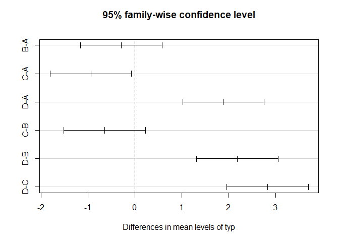

```r
plot( TukeyHSD(ANOVA) )
```

Pomocou post hoc testom sme zistili ze najviac rozdielni vyrobcovia su vyrobca D a C. Pritom podla mean hodnoty ma najlepsie vysledky vyrobca D.

# Príklad 3 (príjem)

**Zadanie:** Súbor údajov prijem.xlsx obsahuje záznamy o 256 osobách. Na danej hladine významnosti testujte, či majú na príjem štatisticky významný vplyv súčasne obe premenné vek a miesto. Pokiaľ áno, post hoc testom určite, ktoré úrovne faktorov sa významne odlišujú. Pokiaľ nie, popíšte, ako by ste to určili. Pohľadom na vhodný graf zhodnoťte, či je interakcia medzi faktormi badateľná. Potom jej významnosť otestujte a interpretujte.

**Riešenie:**

```r
k <- 1
alpha <- 0.05
df <- read_excel("C://Users//ramang//Developer//SMVE-R//Zadania//5_zadanie_ANOVA//prijem.xlsx")



ANOVA <- aov(Prijem ~ (as.factor(Vek) + as.factor(Miesto)), df)
ANOVA %>% summary()
```

```
##                    Df    Sum Sq  Mean Sq F value   Pr(>F)
## as.factor(Vek)      4  28548693  7137173   2.374   0.0531 .
## as.factor(Miesto)   3 131212685 43737562  14.546 1.07e-08 ***
## Residuals         227 682549985  3006828
## ---
## Signif. codes:  0 '***' 0.001 '**' 0.01 '*' 0.05 '.' 0.1 ' ' 1
```

```r
TukeyHSD(ANOVA)
```

```
##   Tukey multiple comparisons of means
##     95% family-wise confidence level
##
## Fit: aov(formula = Prijem ~ (as.factor(Vek) + as.factor(Miesto)), data = df)
##
## $`as.factor(Vek)`
##           diff        lwr        upr     p adj
## 2-1   348.7013  -474.5930 1171.99557 0.7714671
## 3-1   676.8859  -581.1389 1934.91060 0.5768272
## 4-1   502.2998  -441.9567 1446.55633 0.5877220
## 5-1  -831.1840 -2231.7427  569.37481 0.4785825
## 3-2   328.1846  -841.7809 1498.15008 0.9385993
## 4-2   153.5985  -669.6958  976.89278 0.9860096
## 5-2 -1179.8853 -2501.9132  142.14271 0.1050226
## 4-3  -174.5861 -1432.6108 1083.43865 0.9954748
## 5-3 -1508.0698 -3136.7413  120.60161 0.0842403
## 5-4 -1333.4838 -2734.0425   67.07502 0.0704330
##
## $`as.factor(Miesto)`
##          diff       lwr      upr     p adj
## 2-1  504.8643 -444.2760 1454.005 0.5152727
## 3-1 1497.3293  585.3708 2409.288 0.0001826
## 4-1 2008.7403 1078.8692 2938.611 0.0000004
## 3-2  992.4650  209.1619 1775.768 0.0065680
## 4-2 1503.8760  699.7892 2307.963 0.0000142
## 4-3  511.4110 -248.4288 1271.251 0.3044719
```

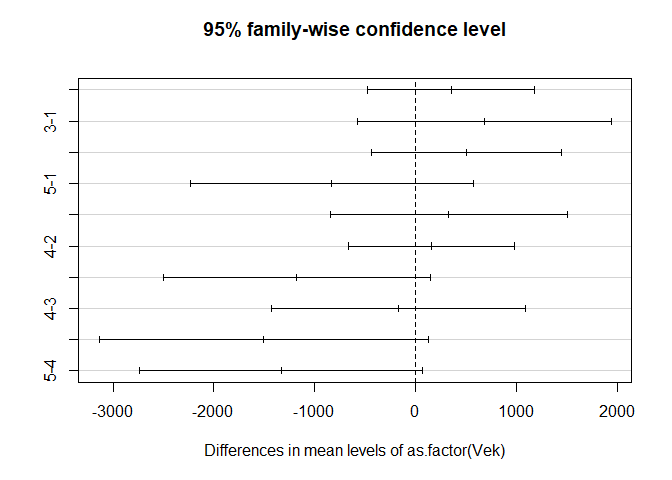

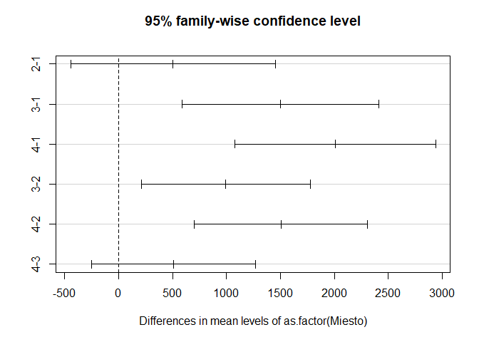

```r
ANOVA %>% TukeyHSD() %>% plot()
```

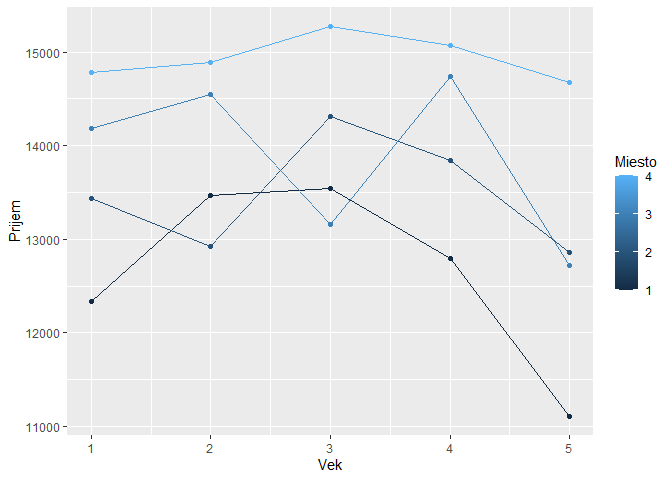

```r
tmp <- df %>%
  dplyr::group_by(Vek, Miesto) %>%
  dplyr::summarize(Prijem = mean(Prijem))
## `summarise()` has grouped output by 'Vek'. You can override using the `.groups` argument.

ggplot(tmp, aes(x = Vek, y = Prijem, color = Miesto, group = Miesto)) +
  geom_point() + geom_line()
```

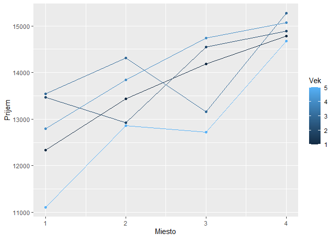

```r
ggplot(tmp, aes(x = Miesto, y = Prijem, color = Vek, group = Vek)) +
  geom_point() + geom_line()
```

Keď sa pozrieme na dané grafy vidíme že miesto má väčšiu váhu ako vek. Ľudia, ktorý pracujú vo väčších mestách majú väčšie príjmi

```r
ANOVA <- aov(Prijem ~ (as.factor(Vek) * as.factor(Miesto)), df)
ANOVA %>% summary()
```

```
##                                   Df    Sum Sq  Mean Sq F value   Pr(>F)
## as.factor(Vek)                     4  28548693  7137173   2.341   0.0561 .
## as.factor(Miesto)                  3 131212685 43737562  14.346 1.48e-08 ***
## as.factor(Vek):as.factor(Miesto)  12  27064812  2255401   0.740   0.7115
## Residuals                        215 655485173  3048768
## ---
## Signif. codes:  0 '***' 0.001 '**' 0.01 '*' 0.05 '.' 0.1 ' ' 1
```

```r
ANOVA %>% summary() %>% getElement(1) %>% {sapply(row.names(.)[-4], function(x) c(
  eta2 = .[x,"Sum Sq"]/sum(.["Sum Sq"]),
  partial.eta2 = .[x,"Sum Sq"]/sum(.[c(x,"Residuals        "),"Sum Sq"])
))} %>% round(3)
```

```
##              as.factor(Vek)                   as.factor(Miesto)
## eta2                                    0.034                            0.156
## partial.eta2                            0.042                            0.167
##              as.factor(Vek):as.factor(Miesto)
## eta2                                    0.032
## partial.eta2                            0.040
```

Tu vidíme že Miesto má aj väčšiu efektivitu na príjem ako Vek. Pomocou hodnoty partial eta.